# examples_func_intro

A relation is expressed as a list of $(x,y)$ ordered pairs.

( 9 , 6 )

( 1 , 5 )

( 8 , 2 )

( 8 , 2 )

( 3 , 7 )

( 7 , 3 )

In order for $y$ to be a function of $x$, each value of $x$ must always have a consistent value of $y$.

- Is this list consistent with $y$ being a function of $x$?

In order for $x$ to be a function of $y$, each value of $y$ must always have a consistent value of $x$.

- Is this list consistent with $x$ being a function of $y$?

In a [one-to-one function](https://en.wikipedia.org/wiki/Injective_function), both $x$ and $y$ are functions of each other.

- Is this list consistent with a one-to-one function?

Every repeated $x$ value is matched with a consistent (also repeating) $y$, and vice versa. This means $y$ is a function of $x$ and $x$ is a function of $y$, and the list is consistent with a one-to-one function.

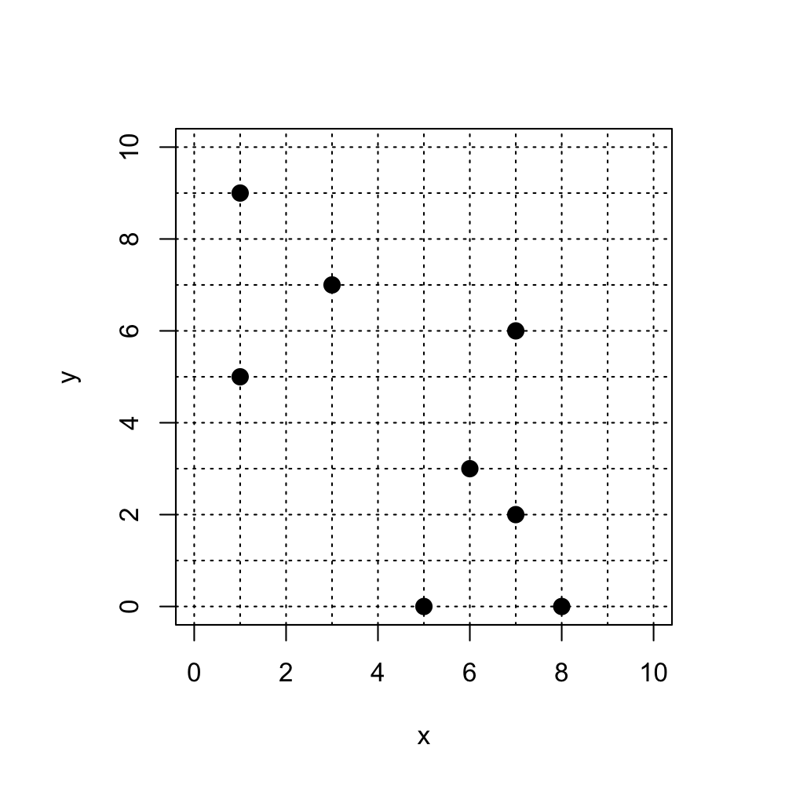

Are these points consistent with $y$ being a function of $x$?

Are these points consistent with $x$ being a function of $y$?

Are these points consistent with a one-to-one function?

It is best to visualize the vertical line test and the horizontal line test. If you can draw a vertical line through 2 (or more) points, then $y$ is not a function of $x$. If you can draw a horizontal line through 2 (or more) points, then $x$ is not a function of $y$.

An $x$ value repeats with different $y$ values, so $y$ is not a function of $x$. The graph fails the vertical line test. For example: (1, 9) and (1, 5)

Also, a $y$ value repeates with different $x$ values, so $x$ is not a function of $y$. The graph fails the horizontal line test. For example: (5, 0) and (8, 0)

We would need both to be function of the other to have a one-to-one function. Neither is, so we don't even have a function in either direction.

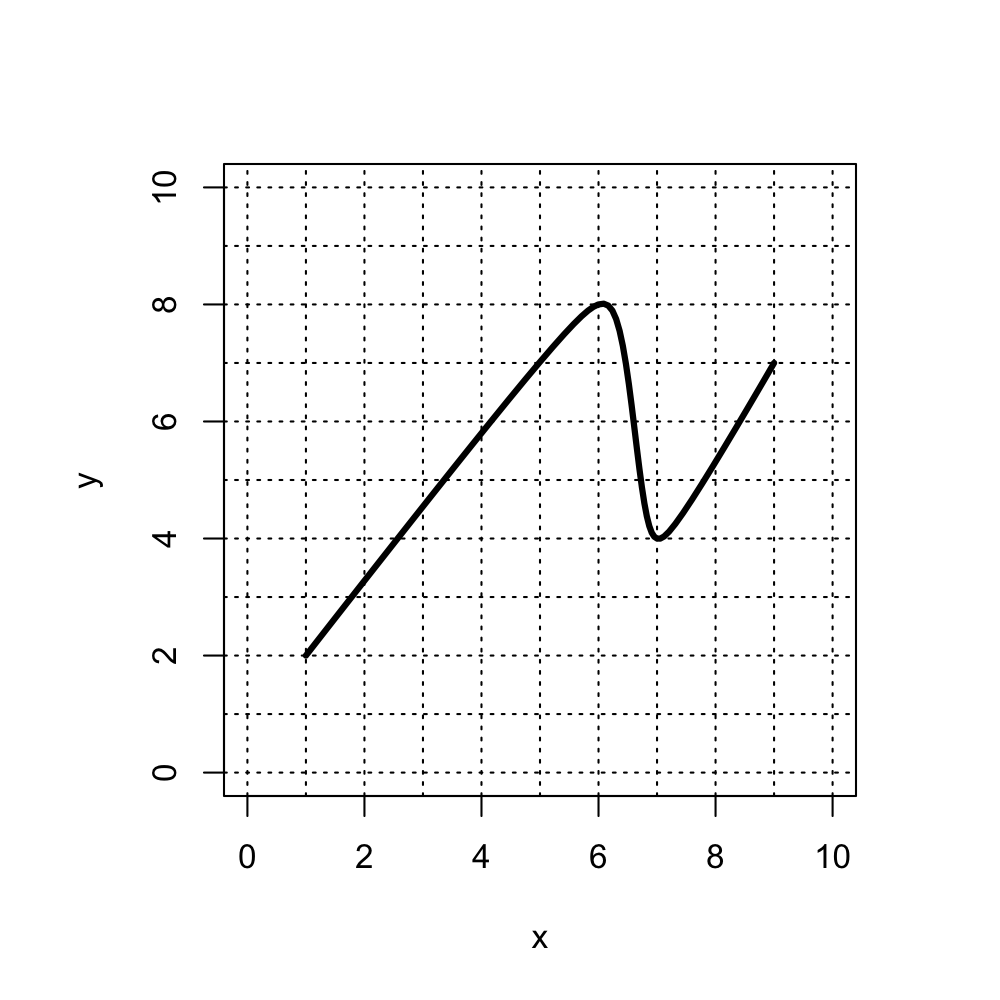

Is this curve consistent with $y$ being a function of $x$?

Is this curve consistent with $x$ being a function of $y$?

Is this curve consistent with a one-to-one function?

It is best to visualize the vertical line test and the horizontal line test. If you can draw a vertical line through 2 (or more) points, then $y$ is not a function of $x$. If you can draw a horizontal line through 2 (or more) points, then $x$ is not a function of $y$.

The function is one-to-one if and only if $y$ is a function of $x$ and $x$ is a function of $y$.

Below, if the function is not one-to-one, some failed line tests are shown:

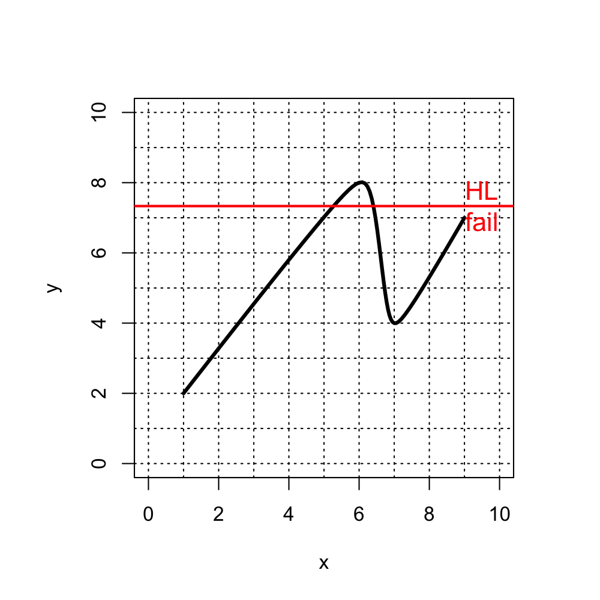

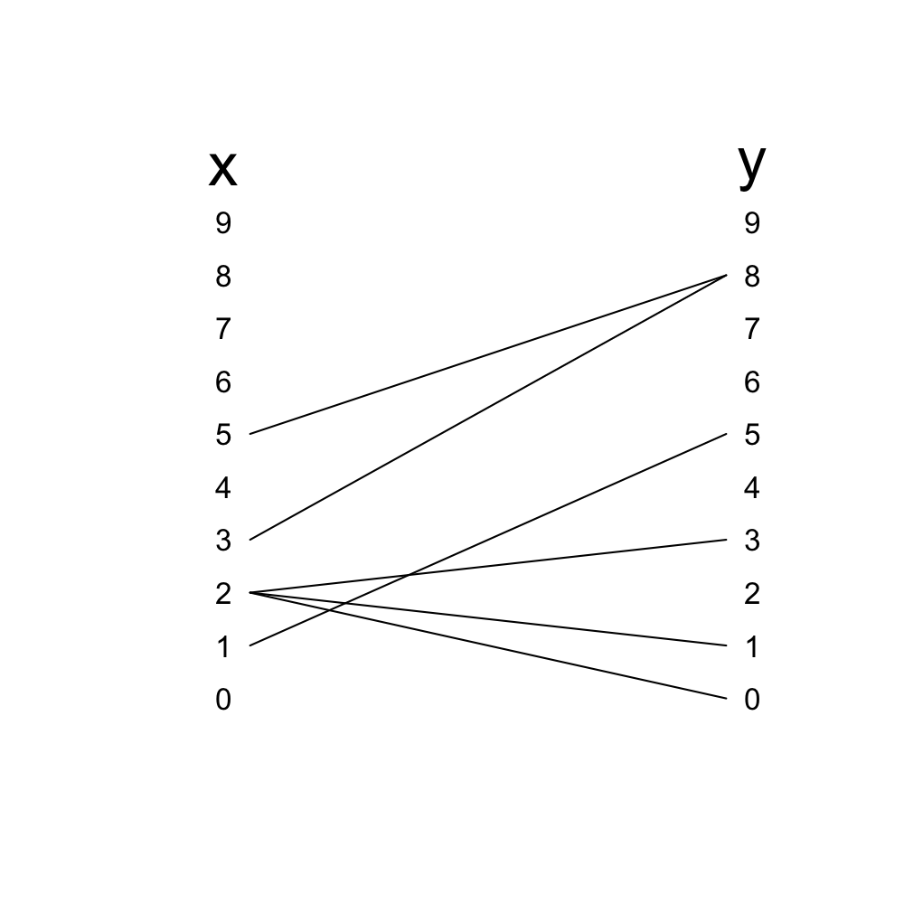

Are these connections consistent with $y$ being a function of $x$?

Are these connections consistent with $x$ being a function of $y$?

Are these connections consistent with a one-to-one function?

If any value of $x$ has two different connections, then $y$ is not a function of $x$. If any value of $y$ has two different connections, then $x$ is not a function of $y$.

An $x$ value has two different connections, so $y$ is not a function of $x$. For example: (2, 1) and (2, 0)

Also, a $y$ value has two different connections, so $x$ is not a function of $y$. For example: (5, 8) and (3, 8)

We would need both to be function of the other to have a one-to-one function. Neither is, so we don't even have a function in either direction.

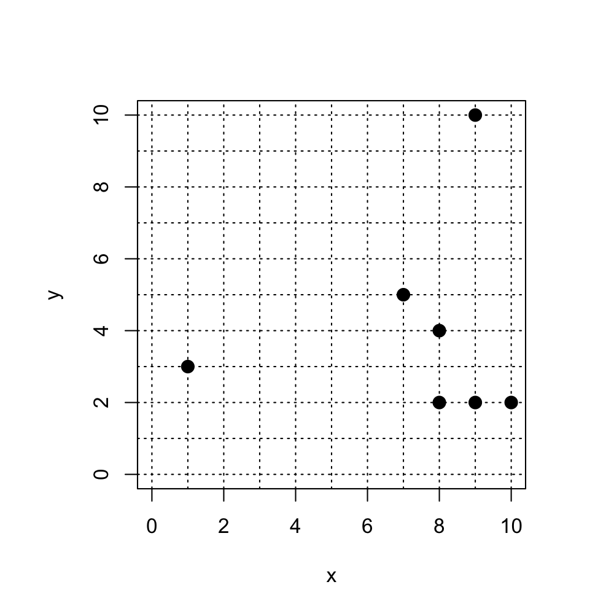

Are these points consistent with $y$ being a function of $x$?

Are these points consistent with $x$ being a function of $y$?

Are these points consistent with a one-to-one function?

It is best to visualize the vertical line test and the horizontal line test. If you can draw a vertical line through 2 (or more) points, then $y$ is not a function of $x$. If you can draw a horizontal line through 2 (or more) points, then $x$ is not a function of $y$.

An $x$ value repeats with different $y$ values, so $y$ is not a function of $x$. The graph fails the vertical line test. For example: (8, 4) and (8, 2)

Also, a $y$ value repeates with different $x$ values, so $x$ is not a function of $y$. The graph fails the horizontal line test. For example: (9, 2) and (8, 2)

We would need both to be function of the other to have a one-to-one function. Neither is, so we don't even have a function in either direction.

A relation is expressed as a list of $(x,y)$ ordered pairs.

( 9 , 3 )

( 8 , 2 )

( 3 , 6 )

( 4 , 7 )

( 4 , 7 )

( 7 , 8 )

( 6 , 2 )

In order for $y$ to be a function of $x$, each value of $x$ must always have a consistent value of $y$.

- Is this list consistent with $y$ being a function of $x$?

In order for $x$ to be a function of $y$, each value of $y$ must always have a consistent value of $x$.

- Is this list consistent with $x$ being a function of $y$?

In a [one-to-one function](https://en.wikipedia.org/wiki/Injective_function), both $x$ and $y$ are functions of each other.

- Is this list consistent with a one-to-one function?

Every repeated $x$ value is matched with a consistent (also repeating) $y$, so $y$ is a function of $x$.

A $y$ value repeates with different $x$ values, so $x$ is not a function of $y$. For example: (8, 2) and (6, 2)

Because $x$ is not a function of $y$, this list is inconsistent with a one-to-one function.

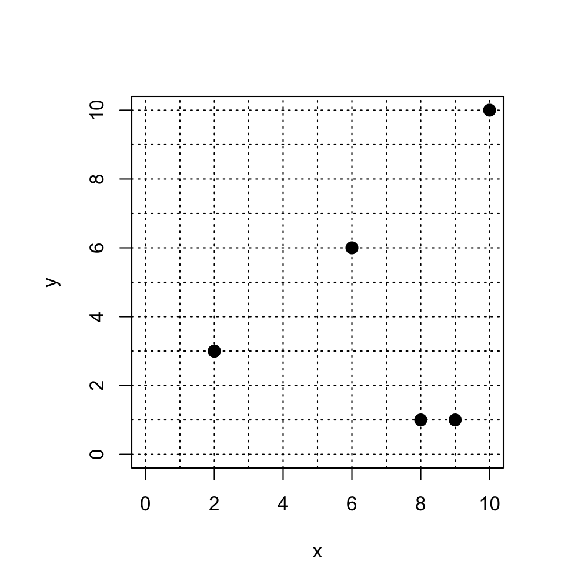

Are these points consistent with $y$ being a function of $x$?

Are these points consistent with $x$ being a function of $y$?

Are these points consistent with a one-to-one function?

It is best to visualize the vertical line test and the horizontal line test. If you can draw a vertical line through 2 (or more) points, then $y$ is not a function of $x$. If you can draw a horizontal line through 2 (or more) points, then $x$ is not a function of $y$.

Every $x$ value has only one $y$ value, so $y$ is a function of $x$. The graph passes the vertical line test.

A $y$ value repeates with different $x$ values, so $x$ is not a function of $y$. The graph fails the horizontal line test. For example: (9, 1) and (8, 1)

Because $x$ is not a function of $y$, these points are inconsistent with a one-to-one function.

A relation is expressed as a list of $(x,y)$ ordered pairs.

( 9 , 8 )

( 4 , 1 )

( 4 , 1 )

( 2 , 4 )

( 3 , 2 )

In order for $y$ to be a function of $x$, each value of $x$ must always have a consistent value of $y$.

- Is this list consistent with $y$ being a function of $x$?

In order for $x$ to be a function of $y$, each value of $y$ must always have a consistent value of $x$.

- Is this list consistent with $x$ being a function of $y$?

In a [one-to-one function](https://en.wikipedia.org/wiki/Injective_function), both $x$ and $y$ are functions of each other.

- Is this list consistent with a one-to-one function?

Every repeated $x$ value is matched with a consistent (also repeating) $y$, and vice versa. This means $y$ is a function of $x$ and $x$ is a function of $y$, and the list is consistent with a one-to-one function.

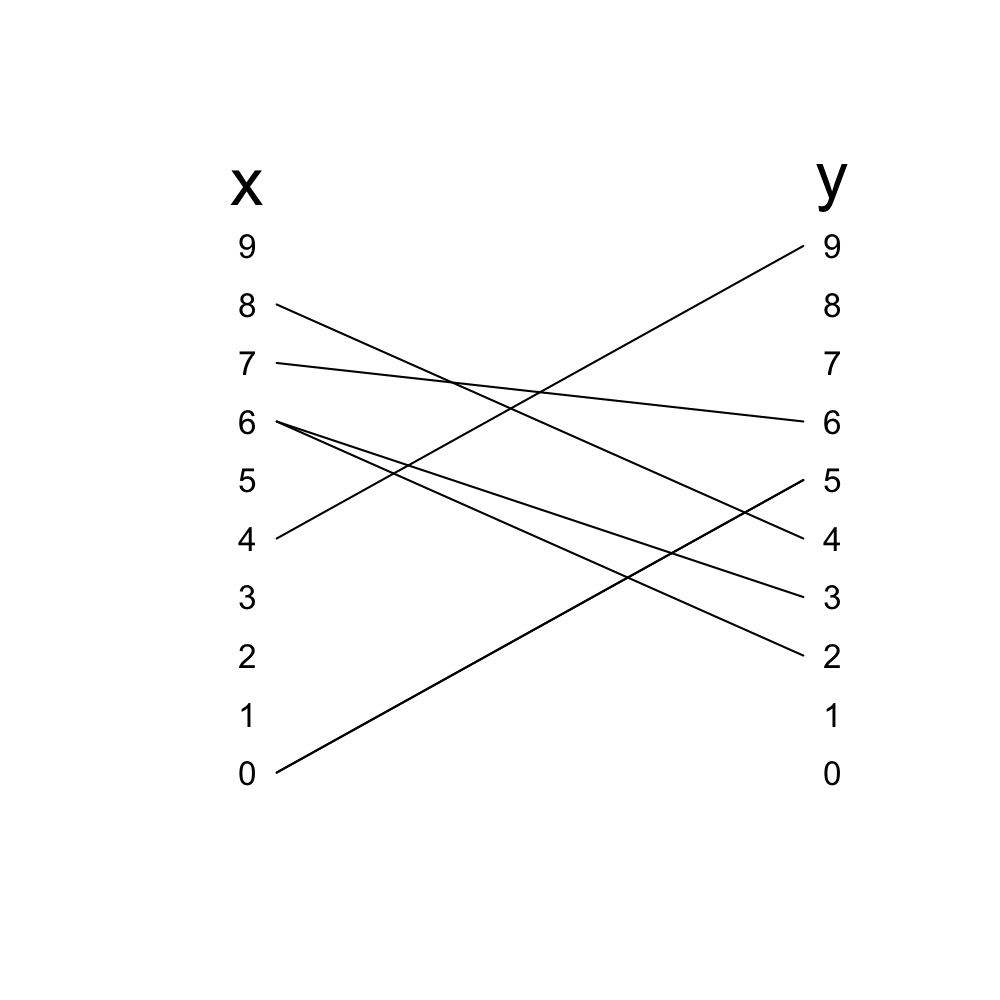

Are these connections consistent with $y$ being a function of $x$?

Are these connections consistent with $x$ being a function of $y$?

Are these connections consistent with a one-to-one function?

If any value of $x$ has two different connections, then $y$ is not a function of $x$. If any value of $y$ has two different connections, then $x$ is not a function of $y$.

An $x$ value has two connections, so $y$ is not a function of $x$. For example: (6, 3) and (6, 2)

Every $y$ value has only one connection, so $x$ is a function of $y$.

Because $y$ is not a function of $x$, these connections are inconsistent with a one-to-one function.

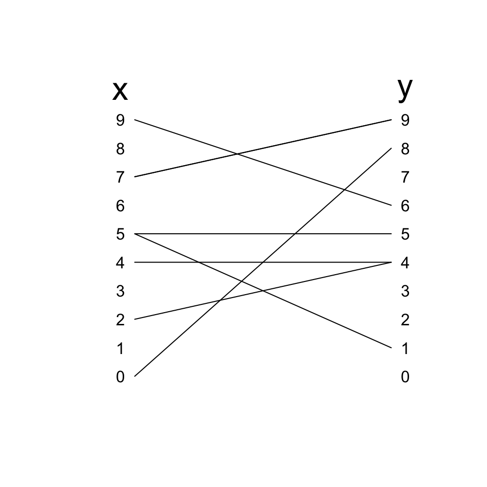

Are these connections consistent with $y$ being a function of $x$?

Are these connections consistent with $x$ being a function of $y$?

Are these connections consistent with a one-to-one function?

If any value of $x$ has two different connections, then $y$ is not a function of $x$. If any value of $y$ has two different connections, then $x$ is not a function of $y$.

An $x$ value has two different connections, so $y$ is not a function of $x$. For example: (5, 1) and (5, 5)

Also, a $y$ value has two different connections, so $x$ is not a function of $y$. For example: (2, 4) and (4, 4)

We would need both to be function of the other to have a one-to-one function. Neither is, so we don't even have a function in either direction.

Consider the functions $f$, $g$, and $h$ shown below.

| x | f(x) | g(x) | h(x) |
| --- | --- | --- | --- |
| 1 | 7 | 8 | 4 |
| 2 | 3 | 9 | 7 |
| 3 | 9 | 7 | 1 |
| 4 | 3 | 6 | 6 |
| 5 | 1 | 9 | 7 |
| 6 | 6 | 7 | 6 |
| 7 | 9 | 9 | 1 |
| 8 | 2 | 3 | 2 |
| 9 | 2 | 1 | 7 |

Evaluate the function expressions below.

- $f(2)~=$
- $g(8)~=$
- $h(1)~=$

To evaluate $f(2)$, start in the FIRST COLUMN, and go down to the row where $x=2$. Then, move to the SECOND COLUMN in the same row, to see that $f(2)~=~3$.

To evaluate $g(8)$, start in the FIRST COLUMN, and go down to the row where $x=8$. Then, move to the THIRD COLUMN in the same row, to see that $g(8)~=~3$.

To evaluate $h(1)$, start in the FIRST COLUMN, and go down to the row where $x=1$. Then, move to the FOURTH COLUMN in the same row, to see that $h(1)~=~4$.

Consider the linear function, $f$, shown in the table below:

| x | f(x) |
| --- | --- |
| 0 | 56 |
| 1 | 59 |
| 2 | 62 |
| 3 | 65 |
| 4 | 68 |
| 5 | 71 |
| 6 | 74 |
| 7 | 77 |
| 8 | 80 |
| 9 | 83 |

What is the output of function $f$ when the argument (the input) is 6? In other words, evaluate $f(6)$.

$$f(6)~=~?$$

Find the row in the table where the input $x=6$ (where the left column has a 6). Find the corresponding output $f$ value in the right column.

$$f(6)~=~74$$

Let function $f$ be defined as follows:

$$f(x)~=~2x+8$$

**Evaluate** $f(-5)$.

In the definition of $f$, replace $x$ with -5.

$$f(-5)~=~ 2\cdot(-5)+8$$

Multiply 2 and -5.

$$f(-5)~=~ -10+8$$

Add/subtract as needed.

$$f(-5)~=~-2$$

Let function $f$ be defined as follows:
$$f(x) = - 5 x^{2} - 4 x +
5$$
**Evaluate** $f(6.75)$.

*You can round (or truncate) at the tenths place.*

Replace all $x$ variables with $6.75$ in the definition of $f$.

$$- 5 (6.75)^{2} - 4 (6.75) +
5$$

You'll want to use a calculator.

$$f(6.75)~=~-249.8125$$

Let function $f$ be defined as follows:

$$f(x)~=~-4x+7$$

**Evaluate** $f(-5)$.

In the definition of $f$, replace $x$ with -5.

$$f(-5)~=~ -4\cdot(-5)+7$$

Multiply -4 and -5.

$$f(-5)~=~ 20+7$$

Add/subtract as needed.

$$f(-5)~=~27$$

Consider the linear function, $f$, shown in the table below:

| x | f(x) |
| --- | --- |
| 0 | 60 |
| 1 | 64 |
| 2 | 68 |
| 3 | 72 |
| 4 | 76 |
| 5 | 80 |
| 6 | 84 |
| 7 | 88 |
| 8 | 92 |
| 9 | 96 |

What is the output of function $f$ when the argument (the input) is 5? In other words, evaluate $f(5)$.

$$f(5)~=~?$$

Find the row in the table where the input $x=5$ (where the left column has a 5). Find the corresponding output $f$ value in the right column.

$$f(5)~=~80$$

Let function $f$ be defined as follows:
$$f(x) = 5 x^{2} - 3 x - 5$$
**Evaluate** $f(3.62)$.

*You can round (or truncate) at the tenths place.*

Replace all $x$ variables with $3.62$ in the definition of $f$.

$$5 (3.62)^{2} - 3 (3.62) - 5$$

You'll want to use a calculator.

$$f(3.62)~=~49.662$$

Consider the linear function, $f$, shown in the table below:

| x | f(x) |
| --- | --- |
| 0 | 45 |
| 1 | 49 |
| 2 | 53 |
| 3 | 57 |
| 4 | 61 |
| 5 | 65 |
| 6 | 69 |
| 7 | 73 |
| 8 | 77 |
| 9 | 81 |

What is the output of function $f$ when the argument (the input) is 3? In other words, evaluate $f(3)$.

$$f(3)~=~?$$

Find the row in the table where the input $x=3$ (where the left column has a 3). Find the corresponding output $f$ value in the right column.

$$f(3)~=~57$$

Consider the linear function, $f$, shown in the table below:

| x | f(x) |
| --- | --- |
| 0 | 56 |
| 1 | 52 |
| 2 | 48 |
| 3 | 44 |
| 4 | 40 |
| 5 | 36 |
| 6 | 32 |
| 7 | 28 |
| 8 | 24 |
| 9 | 20 |

What is the output of function $f$ when the argument (the input) is 6? In other words, evaluate $f(6)$.

$$f(6)~=~?$$

Find the row in the table where the input $x=6$ (where the left column has a 6). Find the corresponding output $f$ value in the right column.

$$f(6)~=~32$$

Consider the linear function, $f$, shown in the table below:

| x | f(x) |
| --- | --- |
| 0 | 42 |
| 1 | 45 |
| 2 | 48 |
| 3 | 51 |
| 4 | 54 |
| 5 | 57 |
| 6 | 60 |
| 7 | 63 |
| 8 | 66 |
| 9 | 69 |

What is the output of function $f$ when the argument (the input) is 6? In other words, evaluate $f(6)$.

$$f(6)~=~?$$

Find the row in the table where the input $x=6$ (where the left column has a 6). Find the corresponding output $f$ value in the right column.

$$f(6)~=~60$$

A function $f$ is graphed below.

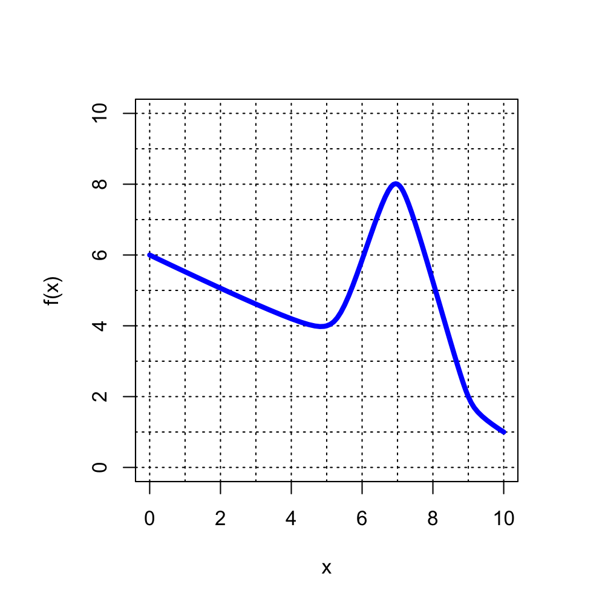

- Evaluate $f(5)$.

Find the correct point on the graph where $x=5$.

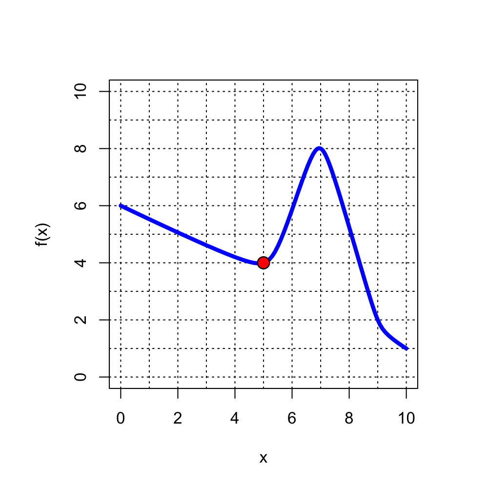

$$f(5)=4$$

A function $f$ is graphed below.

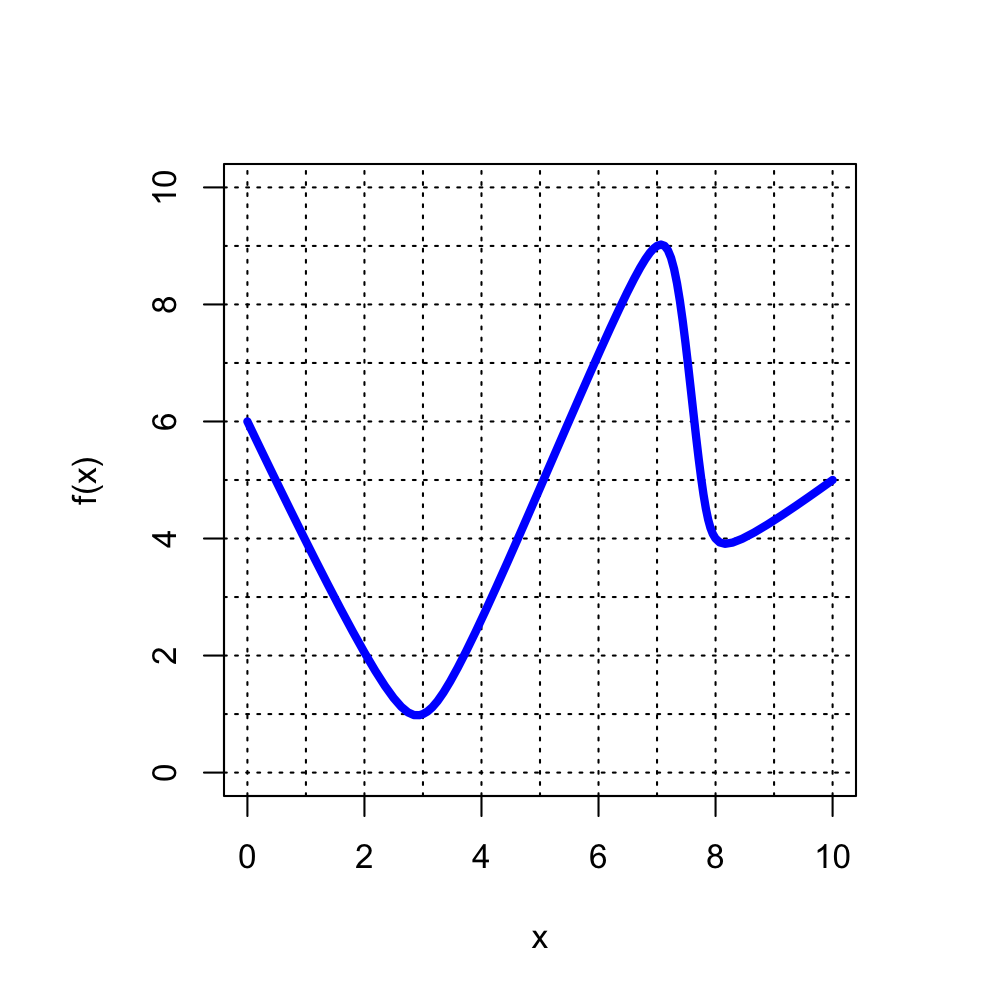

- Evaluate $f(3)$.

Find the correct point on the graph where $x=3$.

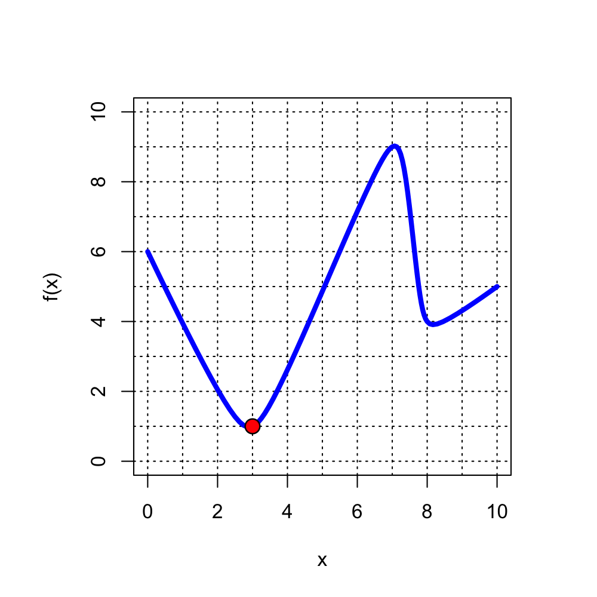

$$f(3)=1$$

A function $f$ is graphed below.

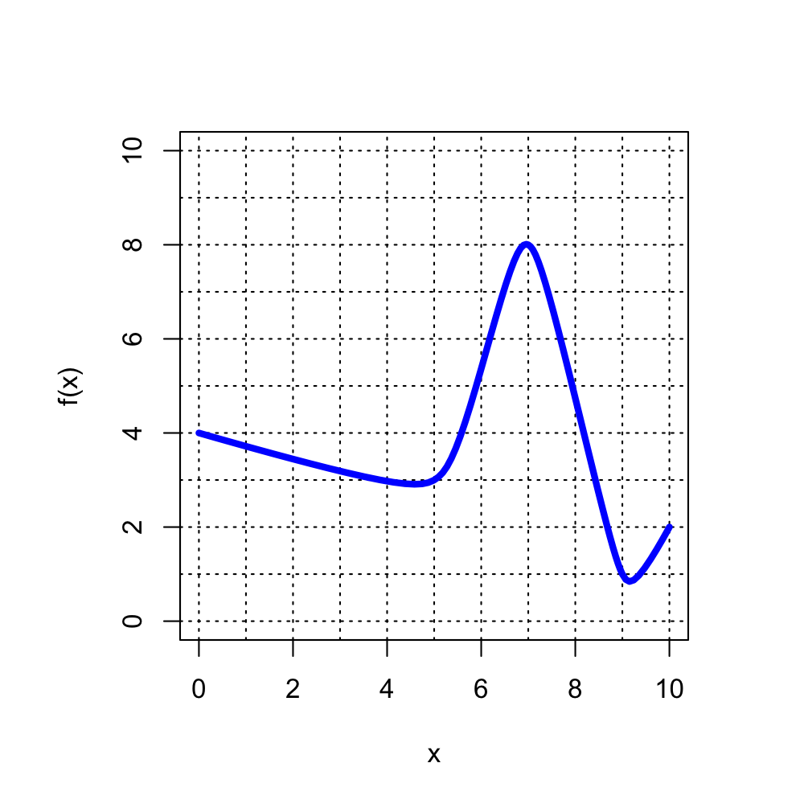

- Evaluate $f(9)$.

Find the correct point on the graph where $x=9$.

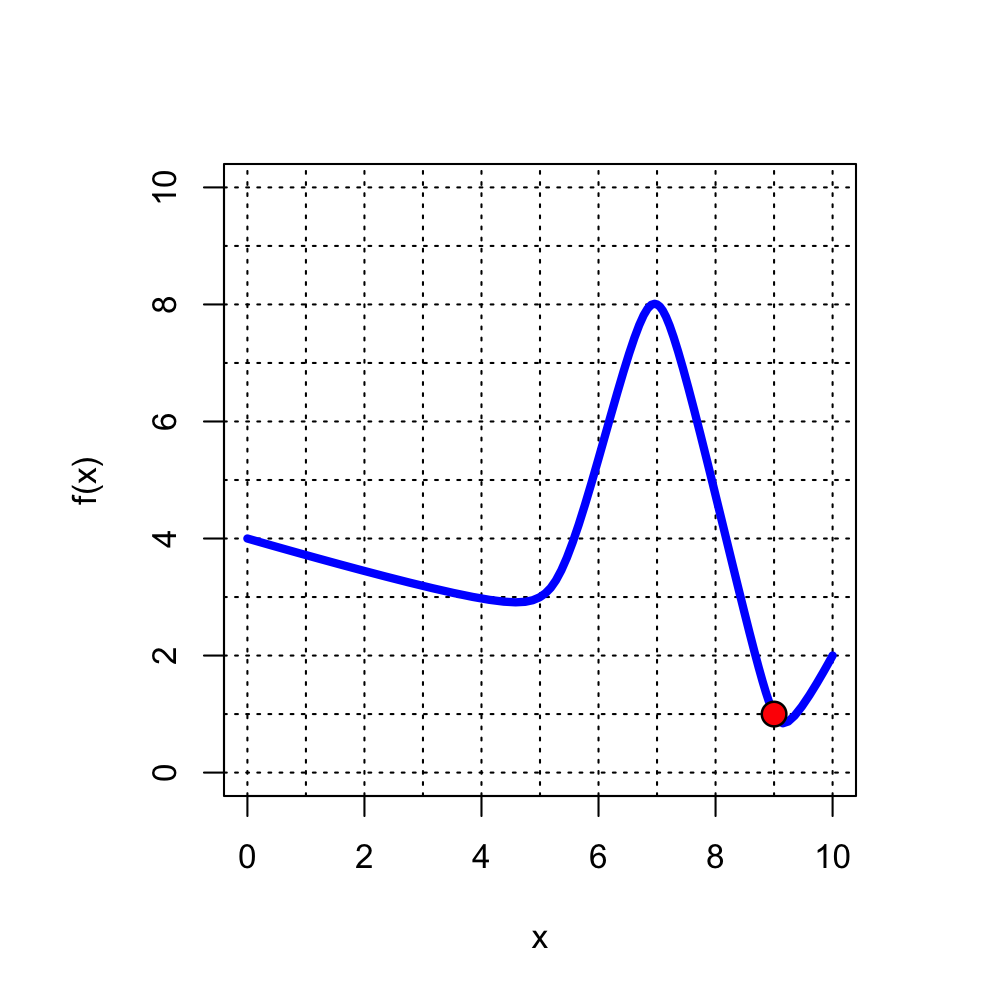

$$f(9)=1$$

A function $f$ is graphed below.

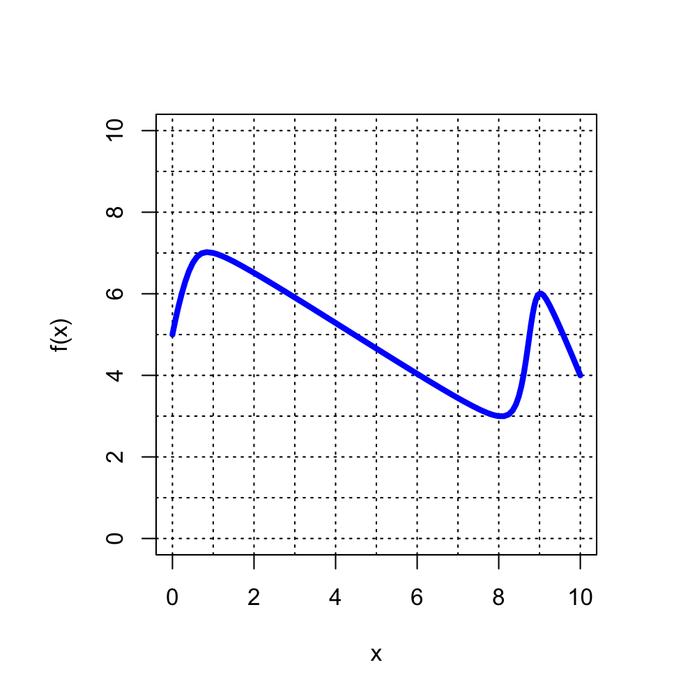

- Evaluate $f(1)$.

Find the correct point on the graph where $x=1$.

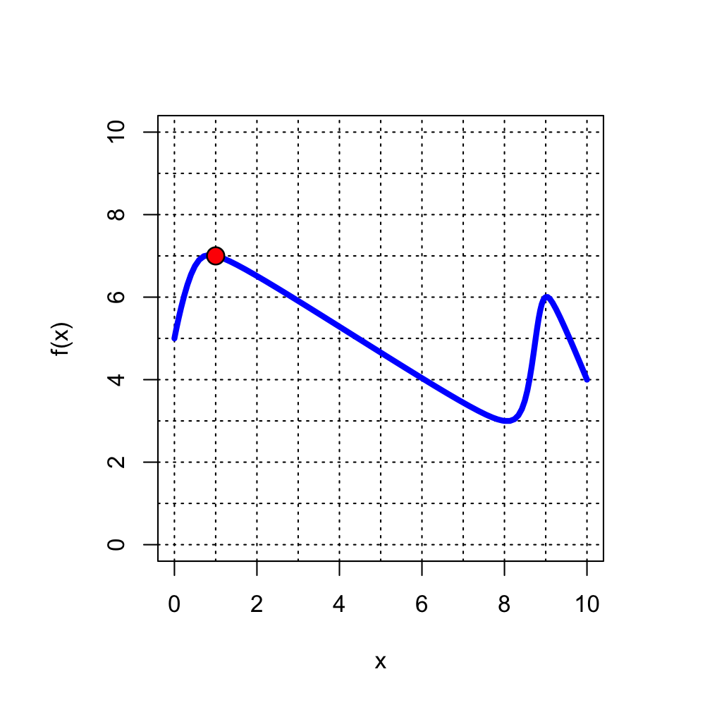

$$f(1)=7$$

A function $f$ is graphed below.

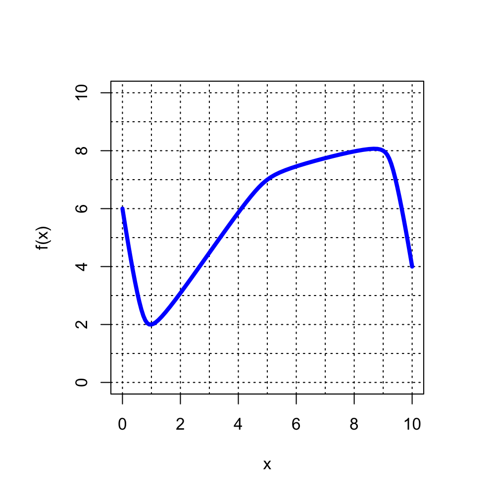

- Evaluate $f(9)$.

Find the correct point on the graph where $x=9$.

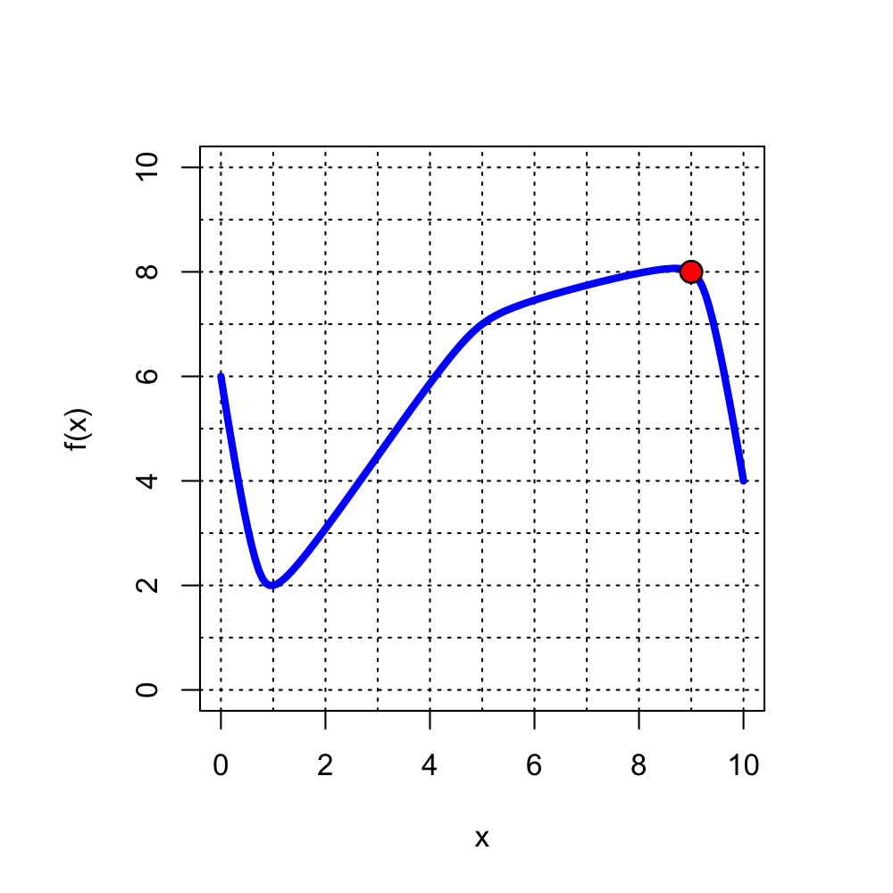

$$f(9)=8$$

A function $f$ is graphed below.

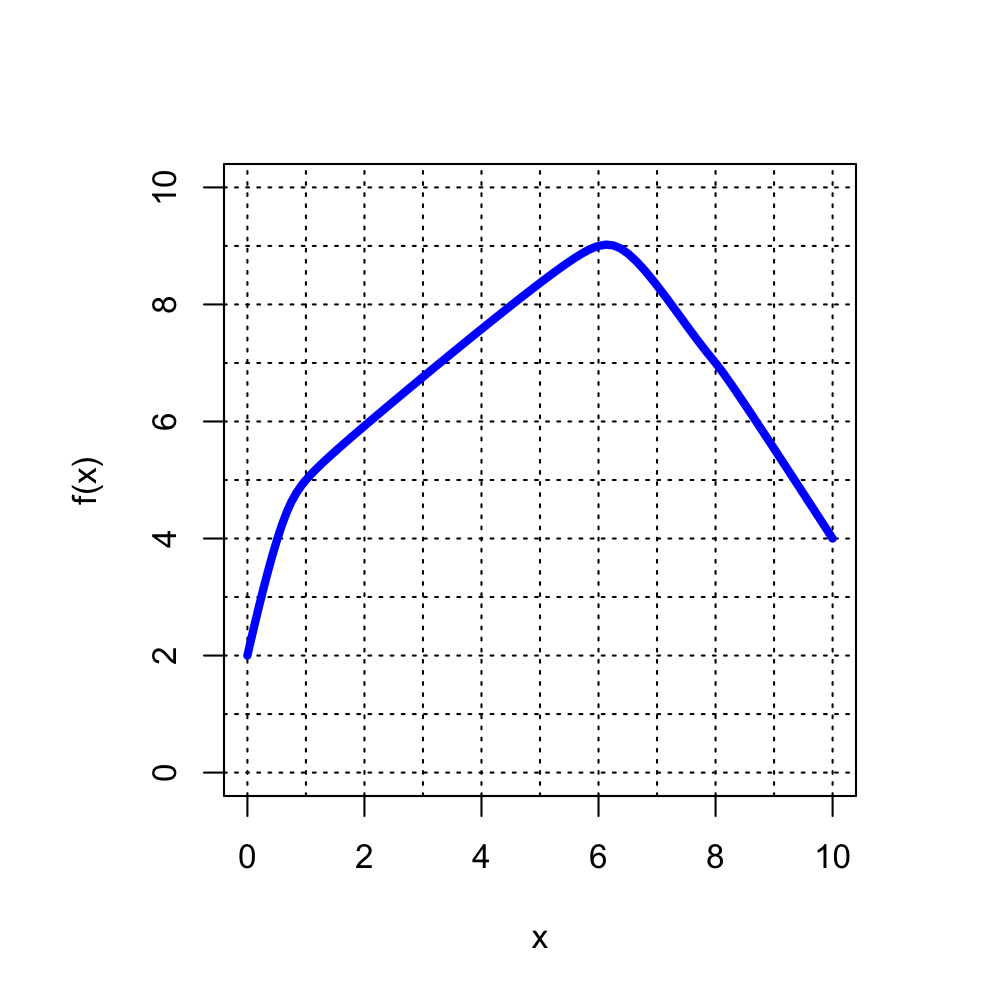

- Evaluate $f(1)$.

Find the correct point on the graph where $x=1$.

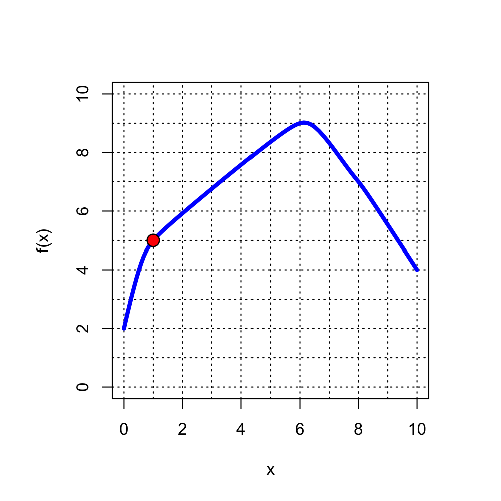

$$f(1)=5$$

A function $f$ is graphed below.

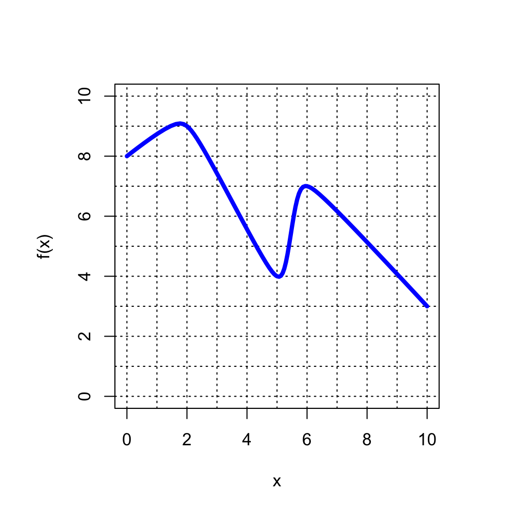

- Evaluate $f(2)$.

Find the correct point on the graph where $x=2$.

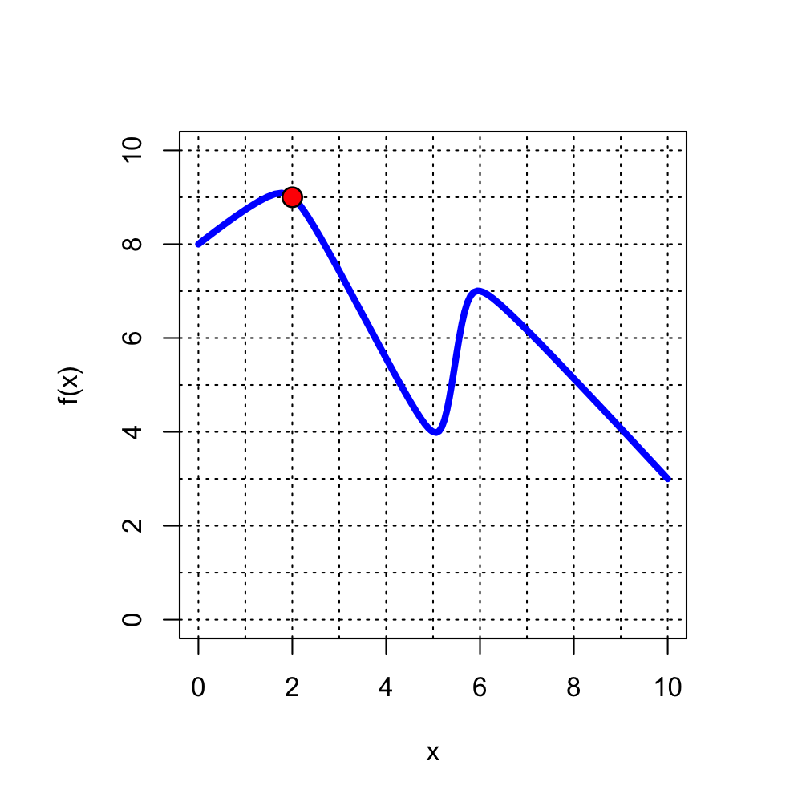

$$f(2)=9$$

A function $f$ is graphed below.

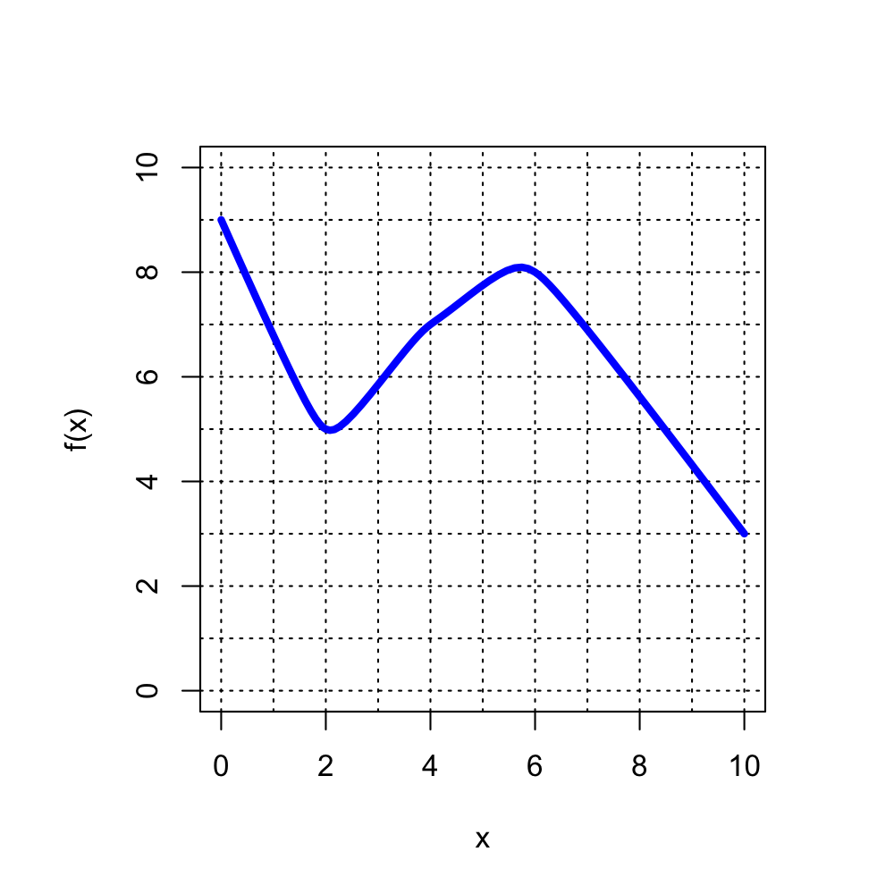

- Evaluate $f(4)$.

Find the correct point on the graph where $x=4$.

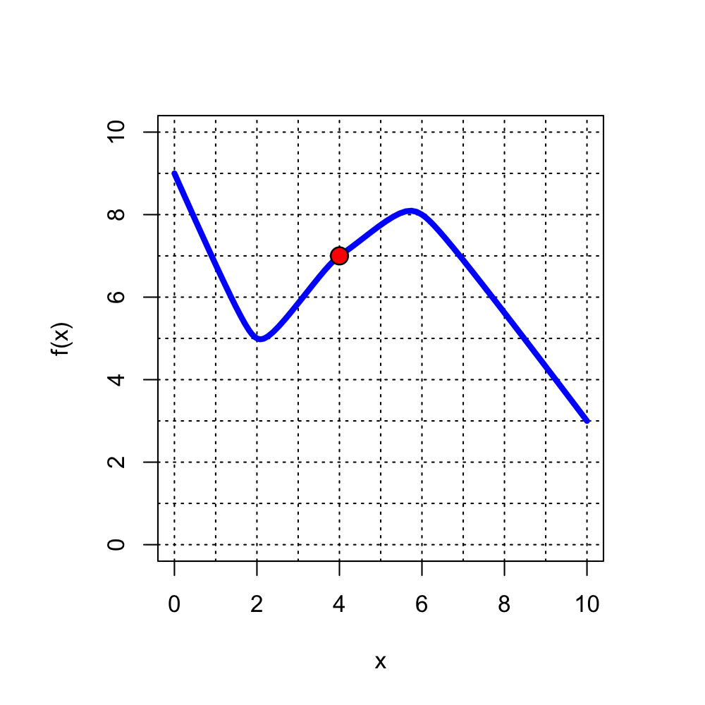

$$f(4)=7$$

A function $f$ is graphed below.

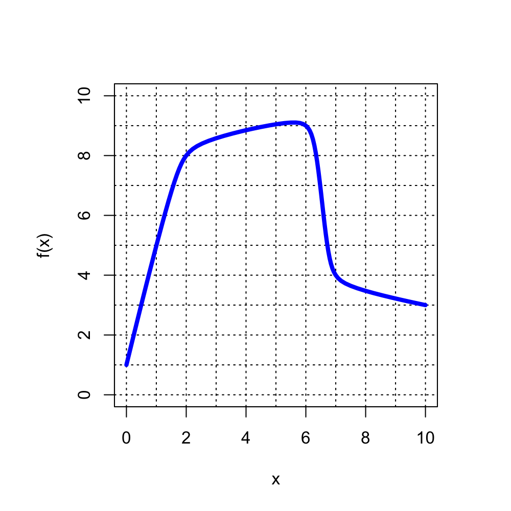

- Evaluate $f(7)$.

Find the correct point on the graph where $x=7$.

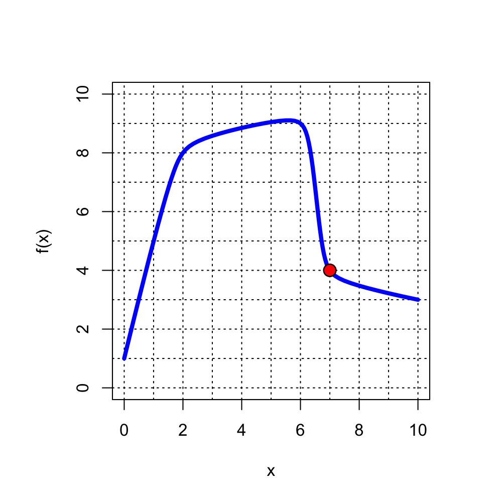

$$f(7)=4$$

A function $f$ is graphed below.

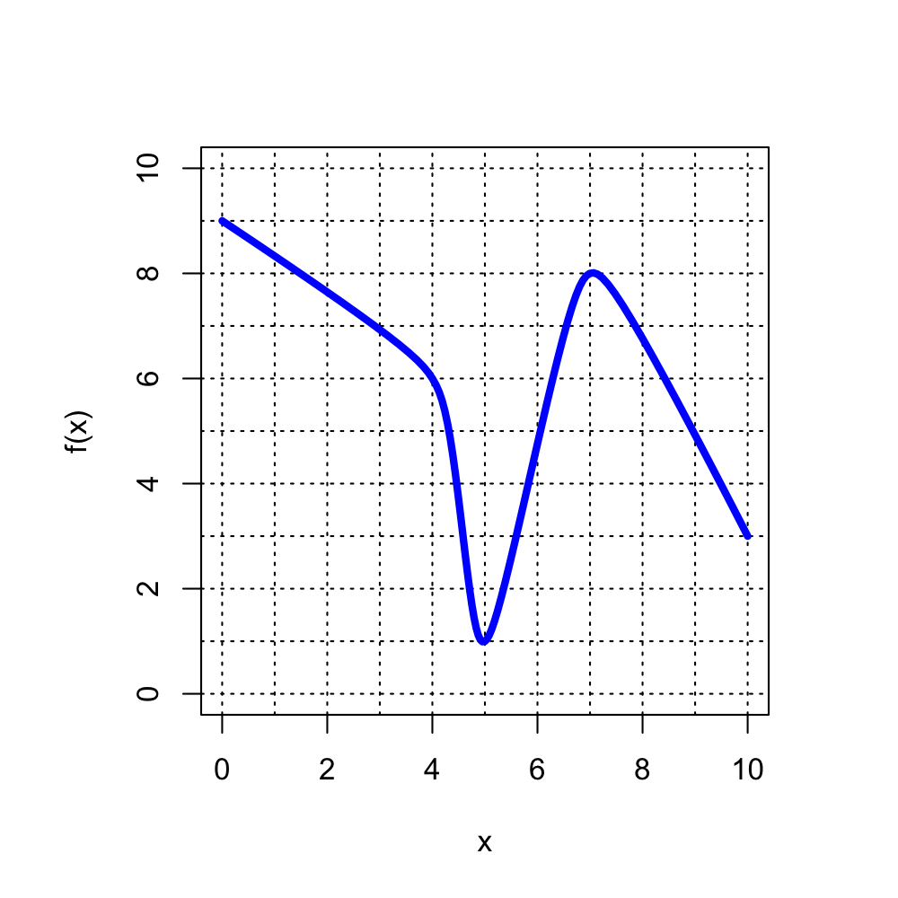

- Evaluate $f(5)$.

Find the correct point on the graph where $x=5$.

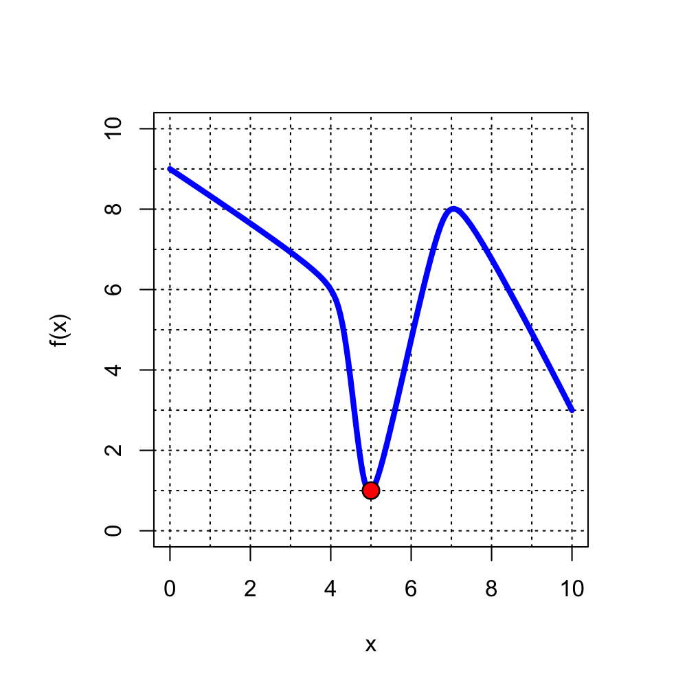

$$f(5)=1$$

A one-to-one function $f$ is graphed below.

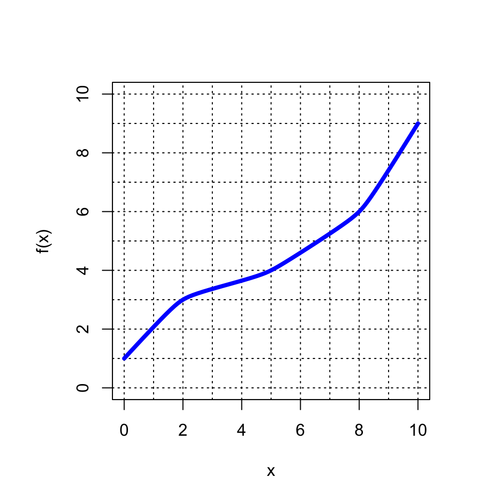

- If $f(x)=4$, then find $x$. In other words, evaluate $f^{-1}(4)$.

Look up [inverse functions](https://en.wikipedia.org/wiki/Inverse_function).

Find the correct point on the graph where $f(x)=4$.

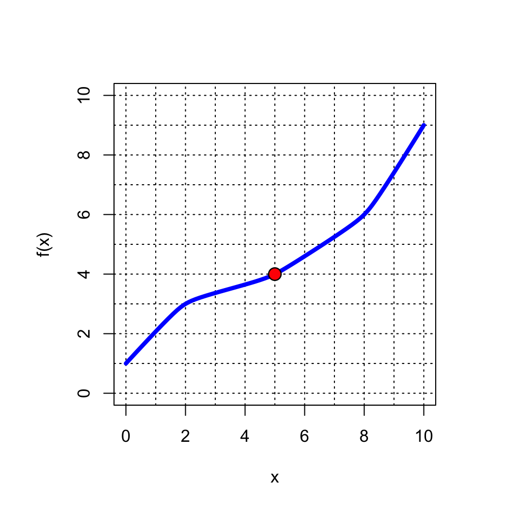

$$f(5)=4$$

Thus,

$$f^{-1}(4) ~=~ 5$$

A one-to-one function $f$ is graphed below.

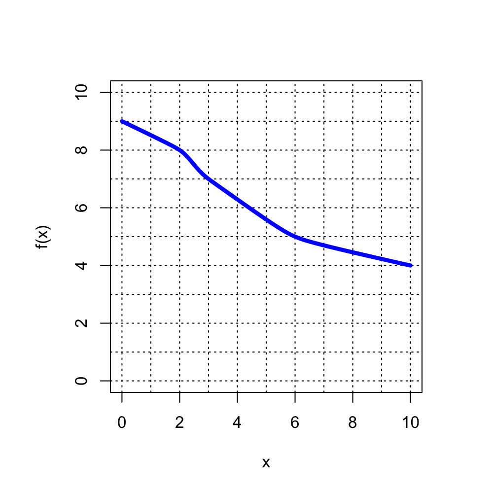

- If $f(x)=8$, then find $x$. In other words, evaluate $f^{-1}(8)$.